# Topic 2-02: Implement ORA from stratch

Zuguang Gu z.gu@dkfz.de

2025-05-22

Implementing ORA is very simple. As long as genes and gene sets are already in the correct ID types, the implementation of ORA only needs a few lines of code.

## Calculate the statistics

There are three input parameters for ORA:

- a vector of (DE) genes: `genes`
- a gene set: `gene_set`
- a vector of background genes: `universe`

With these three objects, we calculate the following statistics:

The number of total genes:

```r
n_universe = length(universe)
```

The number of DE genes:

```r
k = length(genes)
```

The number of genes in each gene set, i.e., the size of each gene set:

```r
m = length(gene_set)
```

And, the number of DE genes in gene sets:

```r
x = length(intersect(gene_set, genes))
```

We put these variables into the 2x2 contigency table:

|  | in the set | not in the set | total |
| --- | --- | --- | --- |
| DE | `x` | - | `k` |
| not DE | - | - | - |
| total | `m` | - | `n_universe` |

Then we can calculate the p-value from the hypergeometric distribution as:

```r
phyper(x - 1, m, n_universe - m, k, lower.tail = FALSE)
```

which is the same as:

```r
phyper(x - 1, k, n_universe - k, m, lower.tail = FALSE)
```

Note, `phyper()` calculates $P(X > x)$, thus we write `phyper(x - 1, ...)` which corresponds to $P(X > x - 1) = P(X \ge x)$.

## Wrap into a function

A quick and dirty way by first implementing a function working on single gene set, then applying it to a list of gene sets.

```r
ora_single = function(genes, gene_set, universe) {
    n_universe = length(universe)
    k = length(genes)

    x = length(intersect(gene_set, genes))
    m = length(gene_set)
    n = n_universe - m

    p = phyper(x - 1, m, n, k, lower.tail = FALSE)

    p
}
ora =  function(genes, gene_sets, universe) {
    ns = length(gene_sets)
    p = numeric(ns)
    for(i in seq_along(gene_sets)) {
        p[i] = ora_single(genes, gene_sets[[i]], universe)
    }
    p
}
```

Or we can do it in a vectorized way:

```r
ora = function(genes, gene_sets, universe) {
    n_universe = length(universe)
    k = length(genes)

    x = sapply(gene_sets, function(x) length(intersect(x, genes)))
    m = sapply(gene_sets, length)
    n = n_universe - m

    p = phyper(x - 1, m, n, k, lower.tail = FALSE)

    data.frame(
        gene_set = names(gene_sets),
        n_hits = x,
        n_genes = k,
        n_gs = m,
        n_total = n_universe,
        p_value = p
    )
}
```

We can further improve the function by:

1. setting the default of `universe` to the total genes in `gene_sets`,
2. intersecting `genes` and `gene_sets` to `universe`. Note this step also removes duplicated genes,
3. adding log2 fold enrichment and adjusted p-values to the result data frame,
4. ordering the result data frame by the significance.

```r
ora = function(genes, gene_sets, universe = NULL) {

    if(is.null(universe)) {
        universe = unique(unlist(gene_sets))
    } else {
        universe = unique(universe)
    }

    genes = intersect(genes, universe)
    gene_sets = lapply(gene_sets, function(x) intersect(x, universe))

    n_universe = length(universe)
    k = length(genes)

    x = sapply(gene_sets, function(x) length(intersect(x, genes)))
    m = sapply(gene_sets, length)
    n = n_universe - m

    p = phyper(x - 1, m, n, k, lower.tail = FALSE)

    df = data.frame(
        gene_set = names(gene_sets),
        hits = x,
        n_genes = k,
        n_gs = m,
        n_universe = n_universe,
        log2fe = log2(x*n_universe/k/m),
        p_value = p
    )

    df$p_adjust = p.adjust(df$p_value, "BH")
    df[order(df$p_adjust, df$p_value), ,drop = FALSE]
}
```

Let’s try our `ora()` with 1000 random genes on the GO gene sets:

```r
library(org.Hs.eg.db)
library(GSEAtutorial)
gs = get_GO_gene_sets_from_orgdb(org.Hs.eg.db, gene_id_type = "ENTREZID")
gs = lapply(gs, unique)  # important!, there are duplicated genes in some GO terms
genes = random_genes(org.Hs.eg.db, 1000, "ENTREZID")

df = ora(genes, gs)
head(df)
```

```
##              gene_set hits n_genes n_gs n_universe    log2fe     p_value
## GO:0006281 GO:0006281   44     827  625      18986 0.6926241 0.001228319
## GO:0048866 GO:0048866    3     827    6      18986 3.5209048 0.001491807
## GO:0009304 GO:0009304    4     827   13      18986 2.8204651 0.001863921
## GO:0016260 GO:0016260    2     827    2      18986 4.5209048 0.001895141
## GO:0034333 GO:0034333    4     827   14      18986 2.7135499 0.002520201
## GO:0015742 GO:0015742    3     827    7      18986 3.2985124 0.002526237
##            p_adjust
## GO:0006281        1
## GO:0048866        1
## GO:0009304        1
## GO:0016260        1
## GO:0034333        1
## GO:0015742        1
```

## Further optimization

We first rename `ora()` to `ora_old()` later for comparison.

```r
ora_old = ora
```

`ora()` is already very fast. However, in the previous implementation, there is still a part which is relatively slow in the function. Let’t first do a profiling.

```r
Rprof()
df = ora(genes, gs)
Rprof(NULL)
summaryRprof()
```

```
## $by.self
##                      self.time self.pct total.time total.pct
## "base::intersect"         2.00    91.74       2.08     95.41
## "duplicated.default"      0.08     3.67       0.08      3.67
## "unlist"                  0.08     3.67       0.08      3.67
## "lapply"                  0.02     0.92       2.10     96.33
##
## $by.total
##                       total.time total.pct self.time self.pct
## "block_exec"                2.18    100.00      0.00     0.00
## "call_block"                2.18    100.00      0.00     0.00
## "doWithOneRestart"          2.18    100.00      0.00     0.00
## "eng_r"                     2.18    100.00      0.00     0.00
## "eval"                      2.18    100.00      0.00     0.00
## "evaluate"                  2.18    100.00      0.00     0.00
## "evaluate::evaluate"        2.18    100.00      0.00     0.00
## "in_dir"                    2.18    100.00      0.00     0.00
## "in_input_dir"              2.18    100.00      0.00     0.00
## "knitr::knit"               2.18    100.00      0.00     0.00
## "ora"                       2.18    100.00      0.00     0.00
## "process_file"              2.18    100.00      0.00     0.00
## "process_group"             2.18    100.00      0.00     0.00
## "render"                    2.18    100.00      0.00     0.00
## "withCallingHandlers"       2.18    100.00      0.00     0.00
## "withOneRestart"            2.18    100.00      0.00     0.00
## "withRestartList"           2.18    100.00      0.00     0.00
## "withRestarts"              2.18    100.00      0.00     0.00
## "withVisible"               2.18    100.00      0.00     0.00
## "with_handlers"             2.18    100.00      0.00     0.00
## "xfun:::handle_error"       2.18    100.00      0.00     0.00
## "lapply"                    2.10     96.33      0.02     0.92
## "base::intersect"           2.08     95.41      2.00    91.74
## "FUN"                       2.08     95.41      0.00     0.00
## "intersect"                 2.08     95.41      0.00     0.00
## "sapply"                    0.18      8.26      0.00     0.00
## "duplicated.default"        0.08      3.67      0.08     3.67
## "unlist"                    0.08      3.67      0.08     3.67
## "duplicated"                0.08      3.67      0.00     0.00
## "unique"                    0.08      3.67      0.00     0.00
##
## $sample.interval
## [1] 0.02
##
## $sampling.time
## [1] 2.18
```

We can see the `intersect()` function consumes more than 90% of the total runtime. `intersect()` internally uses the `match()` function, and there is a faster implementation in the **fastmatch** package. We also optimize the use of the `unlist()` function by adding one additional argument `use.names = FALSE` since we do not care about the names of the unlisted vector.

```r
library(fastmatch)
ora = function(genes, gene_sets, universe = NULL) {

    if(is.null(universe)) {
        universe = unique(unlist(gene_sets, use.names = FALSE))
    } else {
        universe = unique(universe)
    }

    genes = intersect(genes, universe)
    gene_sets = lapply(gene_sets, function(x) x[x %fin% universe])

    n_universe = length(universe)
    k = length(genes)

    x = sapply(gene_sets, function(x) sum(x %fin% genes))
    m = sapply(gene_sets, length)
    n = n_universe - m

    p = phyper(x - 1, m, n, k, lower.tail = FALSE)

    df = data.frame(
        gene_set = names(gene_sets),
        n_hits = x,
        n_genes = k,
        n_gs = m,
        n_total = n_universe,
        log2fe = log2(x*n_universe/k/m),
        p_value = p
    )

    df$p_adjust = p.adjust(df$p_value, "BH")
    df[order(df$p_adjust, df$p_value), ,drop = FALSE]
}
```

Now let’s benchmark `ora_old()` and the new `ora()`:

```r
library(microbenchmark)
microbenchmark(
    ora_old = ora_old(genes, gs),
    ora = ora(genes, gs),
    times = 10
)
```

```
## Unit: milliseconds
##     expr        min         lq       mean     median         uq        max
##  ora_old 2428.50733 2442.32576 2491.56006 2487.00920 2503.38522 2615.92599
##      ora   60.30956   61.03354   65.60052   61.69557   63.54073   99.56895
##  neval
##     10
##     10
```

`ora()` is more than 40x faster than `ora_old()`! We have a very fast implementation of ORA than majority of others from R/Bioconductor.

## More

There is still 5% ~ 10% space for further optimization. Note in the previous `ora()`, `x %fin% universe` actually matches between two character vectors (internally by hash tables). If we can change it to match between two integer vectors, it might further improve the code.

In the next improved implementation, we still use `fmatch()` to perform fast matching. We change genes in objects `genes` and `gene_sets` all to the corresponding integer indicies in `universe`. This is done by `fmatch()`.

```r
ora2 = function(genes, gene_sets, universe = NULL) {

    if(is.null(universe)) {
        universe = unique(unlist(gene_sets, use.names = FALSE))
    } else {
        universe = unique(universe)
    }

    # convert genes to integer indicies
    genes = fmatch(genes, universe); genes = genes[!is.na(genes)]
    gene_sets = lapply(gene_sets, function(x) {
        v = fmatch(x, universe)
        v[!is.na(v)]
    })

    n_universe = length(universe)
    k = length(genes)

    x = sapply(gene_sets, function(x) sum(x %fin% genes)) # now %fin% is applied on integer vectors
    m = sapply(gene_sets, length)
    n = n_universe - m

    p = phyper(x - 1, m, n, k, lower.tail = FALSE)

    df = data.frame(
        gene_set = names(gene_sets),
        n_hits = x,
        n_genes = k,
        n_gs = m,
        n_total = n_universe,
        log2fe = log2(x*n_universe/k/m),
        p_value = p
    )

    df$p_adjust = p.adjust(df$p_value, "BH")
    rownames(df) = df$gene_set
    df[order(df$p_adjust, df$p_value), ,drop = FALSE]
}
```

```r
microbenchmark(
    ora  = ora(genes, gs),
    ora2 = ora2(genes, gs),
    times = 10
)
```

```
## Unit: milliseconds
##  expr      min       lq     mean   median       uq       max neval
##   ora 61.03797 61.55351 69.49227 62.34784 63.15349 100.44114    10
##  ora2 57.02727 57.21476 61.56196 57.60123 58.90798  94.75863    10
```

Let’s make a final version of `ora()`:

```r
ora = function(genes, gene_sets, universe = NULL, min_hits = 3, min_size = 5, max_size = 2500) {

    if(is.null(universe)) {
        universe = unique(unlist(gene_sets, use.names = FALSE))
    } else {
        universe = unique(universe)
    }

    # convert genes to integer indicies
    genes = fmatch(genes, universe); genes = genes[!is.na(genes)]
    gene_sets = lapply(gene_sets, function(x) {
        v = fmatch(x, universe)
        v[!is.na(v)]
    })

    nl = sapply(gene_sets, length)
    gene_sets = gene_sets[nl >= min_size & nl <= max_size]

    n_universe = length(universe)
    k = length(genes)

    x = sapply(gene_sets, function(x) sum(x %fin% genes)) # now %fin% is applied on integer vectors
    m = sapply(gene_sets, length)
    n = n_universe - m

    p = phyper(x - 1, m, n, k, lower.tail = FALSE)

    df = data.frame(
        gene_set = names(gene_sets),
        n_hits = x,
        n_genes = k,
        n_gs = m,
        n_total = n_universe,
        log2fe = log2(x*n_universe/k/m),
        p_value = p
    )

    df = df[df$n_hits >= min_hits, , drop = FALSE]

    df$p_adjust = p.adjust(df$p_value, "BH")
    df = df[order(df$p_adjust, df$p_value), ,drop = FALSE]
    rownames(df) = NULL
    df
}
```

## Practice

#### Practice 1

The file `de.rds` contains results from a differential expression (DE) analysis.

```r
de = readRDS(system.file("extdata", "de.rds", package = "GSEAtutorial"))
de = de[, c("symbol", "p_value")]
de = de[!is.na(de$p_value) & de$symbol != "", ]
head(de)
```

```
##     symbol      p_value
## 1   TSPAN6 0.0081373337
## 2     TNMD 0.0085126916
## 3     DPM1 0.9874656931
## 4    SCYL3 0.2401551938
## 5 C1orf112 0.8884603214
## 6      FGR 0.0006134791
```

Take the `symbol` and `p_value` columns, set cutoff of `p_value` to 0.05, 0.01 and 0.001 respectively to filter the significant DE genes (of course, in applications, you need to correct p-values), apply `ora()` to the three DE gene lists using the GO BP gene sets (think how to obtain the GO gene sets from **org.Hs.eg.db**) and compare the ORA results (the whatever comparison you can think of).

If you EntreZ ID in the gene sets, you need to convert gene symbols for the DE genes to EntreZ IDs. But you can also choose to use gene symbols in the gene sets.

#### Solution

The three DE gene lists:

```r
de_genes_1 = de$symbol[de$p_value < 0.05]
de_genes_2 = de$symbol[de$p_value < 0.01]
de_genes_3 = de$symbol[de$p_value < 0.001]

length(de_genes_1)
```

```
## [1] 2970
```

```r
length(de_genes_2)
```

```
## [1] 1635
```

```r
length(de_genes_3)
```

```
## [1] 790
```

Get the GO BP gene sets. Note genes in `de_genes_*` are symbols, thus genes in gene sets should also be symbols.

```r
gs = get_GO_gene_sets_from_orgdb(org.Hs.eg.db, "BP", gene_id_type = "SYMBOL")
gs[1]
```

```
## $`GO:0000002`
##  [1] "PARP1"    "SLC25A4"  "DNA2"     "TYMP"     "ENDOG"    "LIG3"
##  [7] "MEF2A"    "MPV17"    "OPA1"     "POLG"     "RRM1"     "SSBP1"
## [13] "TOP3A"    "TP53"     "DNAJA3"   "LONP1"    "AKT3"     "POLG2"
## [19] "RRM2B"    "SLC25A36" "TWNK"     "METTL4"   "PIF1"     "SESN2"
## [25] "SLC25A33" "NEURL4"   "MGME1"    "CHCHD4"   "PRIMPOL"  "STOX1"
```

We perform ORA for the three DE gene lists.

```r
tb1 = ora(de_genes_1, gs)
tb2 = ora(de_genes_2, gs)
tb3 = ora(de_genes_3, gs)
```

Compare number of significant GO terms:

```r
sum(tb1$p_adjust < 0.05)
```

```
## [1] 1298
```

```r
sum(tb2$p_adjust < 0.05)
```

```
## [1] 1183
```

```r
sum(tb3$p_adjust < 0.05)
```

```
## [1] 1103
```

Actually we can see gene set enrichment analysis is a robust method which is not sensitive to DE cutoffs (at least for this dataset).

Make a Venn (Euler) diagram:

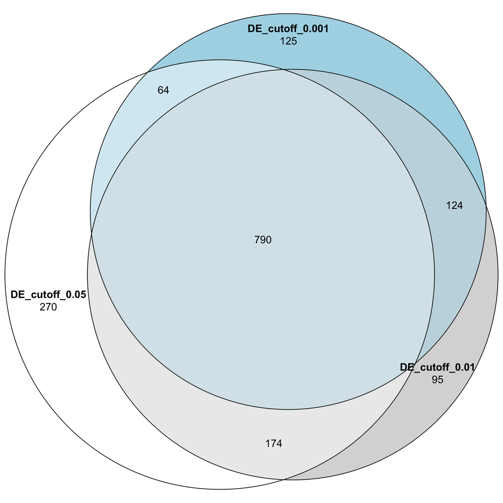

```r
library(eulerr)
plot(euler(list("DE_cutoff_0.05"  = tb1$gene_set[tb1$p_adjust < 0.05],
                "DE_cutoff_0.01"  = tb2$gene_set[tb2$p_adjust < 0.05],
                "DE_cutoff_0.001" = tb3$gene_set[tb3$p_adjust < 0.05])),
     quantities = TRUE)
```

And the Venn diagram for DE genes:

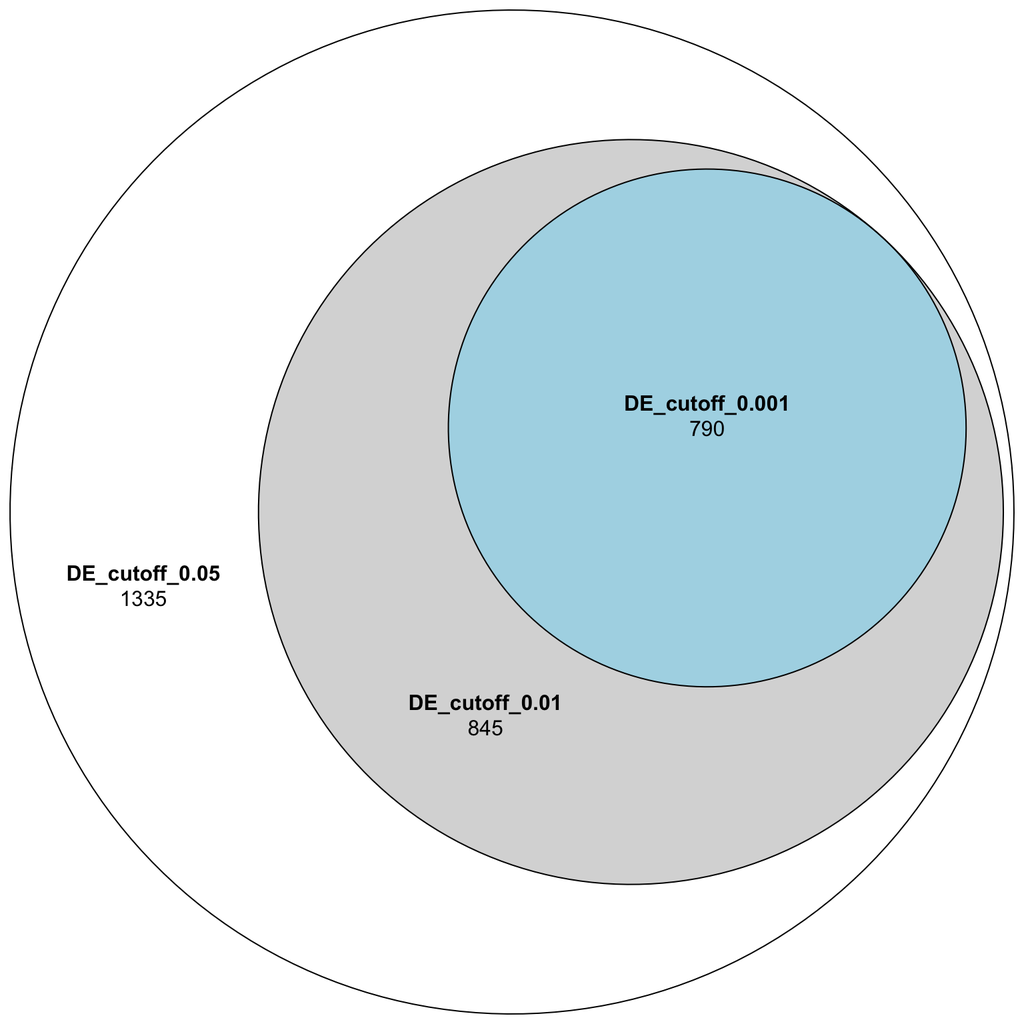

```r
plot(euler(list("DE_cutoff_0.05"  = de_genes_1,
                "DE_cutoff_0.01"  = de_genes_2,
                "DE_cutoff_0.001" = de_genes_3)),
     quantities = TRUE)
```

#### Practice 2

The `ora()` function can be used as the core part of a full-functional function for ORA analysis. Please implement a `ora_go()` for GO analysis

#### Solution

```r
CACHE = new.env(parent = emptyenv())

load_go_genesets = function(org_db, ontology) {
    db_info = dbInfo(dbconn(org_db))
    organism = db_info$value[db_info$name == "ORGANISM"]
    if(is.null(CACHE$go_genesets[[organism]][[ontology]])) {
        suppressMessages(tb <- AnnotationDbi::select(org_db, keys = ontology, keytype = "ONTOLOGYALL", columns = c("ENTREZID", "GOALL")))
        gs = split(tb$ENTREZID, tb$GOALL)
        go_gs = lapply(gs, function(x) {
            as.character(unique(x))
        })

        go_names = Term(GOTERM)[names(go_gs)]

        CACHE$go_genesets[[organism]][[ontology]]$go_names = go_names
        CACHE$go_genesets[[organism]][[ontology]]$go_gs = go_gs
    } else {
        go_names = CACHE$go_genesets[[organism]][[ontology]]$go_names
        go_gs = CACHE$go_genesets[[organism]][[ontology]]$go_gs
    }

    list(names = go_names, gs = go_gs)
}

ora_go = function(genes, org_db = org.Hs.eg.db::org.Hs.eg.db, ontology = "BP", ...) {
    lt = load_go_genesets(org_db, ontology)

    df = ora(genes, lt$gs, ...)
    df$description = lt$names[df$gene_set]
    df
}

load_kegg_genesets = function(organism, db) {
    if(is.null(CACHE$kegg_pathways[[db]][[organism]])) {
        if(db == "pathway") {
            gs_names = read.table(url(paste0("https://rest.kegg.jp/list/", db, "/", organism)), sep = "\t", quote = "")
        } else {
            gs_names = read.table(url(paste0("https://rest.kegg.jp/list/", db)), sep = "\t", quote = "")
        }
        gs_names = structure(gs_names[, 2], names = gs_names[, 1])

        gs_genes = read.table(url(paste0("https://rest.kegg.jp/link/", db, "/", organism)), sep = "\t", quote = "")
        gs_genes[, 1] = gsub("^\\w+:", "", gs_genes[, 1])
        gs_genes[, 2] = gsub("^\\w+:", "", gs_genes[, 2])
        if(db == "module") {
            gs_genes[, 2] = gsub("^[a-zA-Z]+_", "", gs_genes[, 2])
        }

        gs = split(gs_genes[, 1], gs_genes[, 2])
        gs = lapply(gs, function(x) {
            as.character(unique(x))
        })

        CACHE$kegg_pathways[[db]][[organism]]$gs_names = gs_names
        CACHE$kegg_pathways[[db]][[organism]]$gs = gs
    } else {
        gs_names = CACHE$kegg_pathways[[db]][[organism]]$gs_names
        gs = CACHE$kegg_pathways[[db]][[organism]]$gs
    }

    list(names = gs_names, gs = gs)
}

# db: pathway, module, ko, network, disease, drug
ora_kegg = function(genes, organism = "hsa", db = "pathway", ...) {
    lt = load_kegg_genesets(organism, db)

    df = ora(genes, lt$gs, ...)
    df$description = lt$names[df$gene_set]
    df
}


load_msigdb_genesets = function(collection, version) {
    dataset = paste0(version, "/", collection)
    if(is.null(CACHE$msigdb_genesets[[dataset]])) {
        gs = get_msigdb(version = version, collection = collection)
        CACHE$msigdb_genesets[[dataset]] = gs
    } else {
        gs = CACHE$msigdb_genesets[[dataset]]
    }

    list(gs = gs)
}

ora_msigdb = function(genes, collection = "h.all", version = "2024.1.Hs", ...) {
    lt = load_msigdb_genesets(collection, version)

    df = ora(genes, lt$gs, ...)
    df
}

library(reactome.db)
load_reactome_genesets = function(organism) {
    if(is.null(CACHE$reactome_pathways)) {
        pathway_names = as.list(reactomePATHID2NAME)
        pathway_gs = as.list(reactomePATHID2EXTID)

        cn = intersect(names(pathway_names), names(pathway_gs))
        pathway_names = pathway_names[cn]
        pathway_gs = pathway_gs[cn]

        CACHE$reactome_pathways$pathway_gs = pathway_gs
        CACHE$reactome_pathways$pathway_names = pathway_names
    } else {
        pathway_gs = CACHE$reactome_pathways$pathway_gs
        pathway_names = CACHE$reactome_pathways$pathway_names
    }

    l = grepl(paste0("^R-", organism, "-"), names(pathway_names))
    list(names = pathway_names[l], gs = pathway_gs[l])
}

ora_reactome = function(genes, organism = "HSA", ...) {
    lt = load_reactome_genesets(organism)

    df = ora(genes, lt$gs, ...)
    df$description = lt$names[df$gene_set]
    df
}

library(UniProtKeywords)
ora_keywords = function(genes, organism = "human", ...) {
    gs = load_keyword_genesets(organism)
    df = ora(genes, gs, ...)
    df
}

library(simona)
load_simona_genesets = function(fun, ontology, organism = "human", ...) {
    if(is.null(CACHE$simona_genesets[[ontology]][[organism]])) {
        dag = fun(organism)
        mc = mcols(dag)
        gs_names = structure(mc$name, names = rownames(mc))
        all_terms = dag_all_terms(dag)
        gs = term_annotations(dag, all_terms)
        gs_names = gs_names[all_terms]

        org_db = switch(organism,
            human = org.Hs.eg.db::org.Hs.eg.db,
            mouse = org.Ms.eg.db::org.Ms.eg.db,
            rat   = org.Rn.eg.db::org.Rn.eg.db,
            stop("not supported")
        )

        x = keys(org_db, keytype = "SYMBOL")
        suppressMessages(map_tb <- AnnotationDbi::select(org_db, keys = x, keytype = "SYMBOL", columns = c("ENTREZID", "GENETYPE")))
        map_tb = map_tb[map_tb$GENETYPE == "protein-coding", , drop = FALSE]
        map_tb = map_tb[!duplicated(map_tb[, 1]), , drop = FALSE]
        map = structure(map_tb[, 2], names = map_tb[, 1])

        gs = lapply(gs, function(x) {
            x2 = map[x]
            unique(x2[!is.na(x2)])
        })

        n = sapply(gs, length)
        gs = gs[n > 0]
        gs_names = gs_names[n > 0]

        CACHE$simona_genesets[[ontology]][[organism]]$gs = gs
        CACHE$simona_genesets[[ontology]][[organism]]$gs_names = gs_names
    } else {
        gs = CACHE$simona_genesets[[ontology]][[organism]]$gs
        gs_names = CACHE$simona_genesets[[ontology]][[organism]]$gs_names
    }

    list(gs = gs, names = gs_names)
}

# the human phenotype ontology
ora_phenotype = function(genes, organism = "human", ...) {
    lt = load_simona_genesets(ontology_hp, "hp", organism = organism)

    df = ora(genes, lt$gs, ...)
    df$description = lt$names[df$gene_set]
    df
}

# disease ontology
ora_disease = function(genes, organism = "human", ...) {
    lt = load_simona_genesets(ontology_rdo, "rdo", organism = organism)

    df = ora(genes, lt$gs, ...)
    df$description = lt$names[df$gene_set]
    df
}
```

Let’s test these `ora_*()` functions.

```r
genes = random_genes(org.Hs.eg.db, 1000)
head(ora_go(genes))
```

```
##     gene_set n_hits n_genes n_gs n_total    log2fe      p_value  p_adjust
## 1 GO:0010647    110     843 1837   18986 0.4314833 0.0006833767 0.4132021
## 2 GO:0023056    110     843 1838   18986 0.4306982 0.0006967040 0.4132021
## 3 GO:0007617      7     843   36   18986 2.1306895 0.0008961843 0.4132021
## 4 GO:1902533     73     843 1137   18986 0.5320676 0.0009434264 0.4132021
## 5 GO:0009967     98     843 1624   18986 0.4426335 0.0010623450 0.4132021
## 6 GO:0007189     18     843  184   18986 1.1396226 0.0014366804 0.4132021
##                                                                 description
## 1                                 positive regulation of cell communication
## 2                                          positive regulation of signaling
## 3                                                           mating behavior
## 4                  positive regulation of intracellular signal transduction
## 5                                positive regulation of signal transduction
## 6 adenylate cyclase-activating G protein-coupled receptor signaling pathway
```

```r
head(ora_kegg(genes))
```

```
##   gene_set n_hits n_genes n_gs n_total    log2fe      p_value   p_adjust
## 1 hsa05340      8     397   38    8866 2.2331449 0.0002254206 0.05342468
## 2 hsa04936     15     397  144    8866 1.2180380 0.0019373356 0.22957427
## 3 hsa04014     20     397  238    8866 0.9081828 0.0049693463 0.39257836
## 4 hsa04072     13     397  149    8866 0.9623436 0.0160575786 0.58501606
## 5 hsa04064     10     397  105    8866 1.0887550 0.0189047779 0.58501606
## 6 hsa05203     16     397  205    8866 0.8015924 0.0215397003 0.58501606
##                                                description
## 1          Primary immunodeficiency - Homo sapiens (human)
## 2           Alcoholic liver disease - Homo sapiens (human)
## 3             Ras signaling pathway - Homo sapiens (human)
## 4 Phospholipase D signaling pathway - Homo sapiens (human)
## 5      NF-kappa B signaling pathway - Homo sapiens (human)
## 6              Viral carcinogenesis - Homo sapiens (human)
```

```r
head(ora_msigdb(genes))
```

```
##                           gene_set n_hits n_genes n_gs n_total    log2fe
## 1     HALLMARK_PANCREAS_BETA_CELLS      6     207   40    4384 1.6675795
## 2 HALLMARK_CHOLESTEROL_HOMEOSTASIS      8     207   74    4384 1.1950918
## 3              HALLMARK_MYOGENESIS     14     207  200    4384 0.5680439
## 4          HALLMARK_G2M_CHECKPOINT     13     207  200    4384 0.4611287
## 5   HALLMARK_FATTY_ACID_METABOLISM     10     207  158    4384 0.4226925
## 6 HALLMARK_PI3K_AKT_MTOR_SIGNALING      7     207  105    4384 0.4976545
##      p_value  p_adjust
## 1 0.01030418 0.3915590
## 2 0.02228571 0.4234285
## 3 0.08822987 0.9349388
## 4 0.14854918 0.9349388
## 5 0.21139752 0.9349388
## 6 0.22598929 0.9349388
```

```r
head(ora_reactome(genes))
```

```
##        gene_set n_hits n_genes n_gs n_total   log2fe     p_value  p_adjust
## 1  R-HSA-198933     15     529  134   11422 1.273205 0.001338105 0.6305247
## 2  R-HSA-189200      5     529   21   11422 2.362014 0.002293860 0.6305247
## 3  R-HSA-201688      3     529    9   11422 2.847441 0.006729736 0.6305247
## 4 R-HSA-8964038      4     529   20   11422 2.110476 0.012194576 0.6305247
## 5 R-HSA-9832991      3     529   11   11422 2.557935 0.012335110 0.6305247
## 6   R-HSA-77286      3     529   11   11422 2.557935 0.012335110 0.6305247
##    description
## 1 Homo sap....
## 2 Homo sap....
## 3 Homo sap....
## 4 Homo sap....
## 5 Homo sap....
## 6 Homo sap....
```

```r
head(ora_keywords(genes))
```

```
##                    gene_set n_hits n_genes n_gs n_total    log2fe     p_value
## 1 Congenital erythrocytosis      3     881    6   18050 3.3567130 0.002074016
## 2                ANK repeat     22     881  235   18050 0.9396277 0.002679690
## 3            Pharmaceutical      7     881   48   18050 1.5791054 0.008260505
## 4                    Asthma      3     881   12   18050 2.3567130 0.018311443
## 5                TPR repeat     14     881  158   18050 0.8602872 0.022712632
## 6    Multifunctional enzyme      8     881   73   18050 1.1668884 0.025528799
##    p_adjust
## 1 0.2786878
## 2 0.2786878
## 3 0.5433348
## 4 0.5433348
## 5 0.5433348
## 6 0.5433348
```

```r
head(ora_phenotype(genes))
```

```
##     gene_set n_hits n_genes n_gs n_total   log2fe      p_value  p_adjust
## 1 HP:0001901      8     548   32   11426 2.382001 0.0001006451 0.2207147
## 2 HP:0020061      6     548   20   11426 2.645035 0.0002577701 0.2540750
## 3 HP:0001900      5     548   14   11426 2.896574 0.0003475718 0.2540750
## 4 HP:0031404     10     548   60   11426 1.797038 0.0005119319 0.2806667
## 5 HP:0011839     15     548  126   11426 1.311611 0.0010089837 0.3388509
## 6 HP:0025539      7     548   35   11426 2.060073 0.0011688887 0.3388509
##                                      description
## 1                                   Polycythemia
## 2              Abnormal hemoglobin concentration
## 3 Increased circulating hemoglobin concentration
## 4             Impaired antigen-specific response
## 5                          Abnormal T cell count
## 6            Abnormal B cell subset distribution
```

```r
head(ora_disease(genes))
```

```
##       gene_set n_hits n_genes n_gs n_total    log2fe     p_value  p_adjust
## 1    DOID:1148     32     796  394   16654 0.7649047 0.002475985 0.9946687
## 2 DOID:9001521      3     796    7   16654 3.1645641 0.003294136 0.9946687
## 3 DOID:9008598      3     796    8   16654 2.9719190 0.005084206 0.9946687
## 4 DOID:9006013      3     796    9   16654 2.8019940 0.007357263 0.9946687
## 5 DOID:9005520      4     796   17   16654 2.2994936 0.007485213 0.9946687
## 6   DOID:13809      4     796   18   16654 2.2170315 0.009265643 0.9946687
##                         description
## 1                       polydactyly
## 2                 Subdural Hematoma
## 3 Traumatic Intracranial Hemorrhage
## 4                          Hematoma
## 5           Genitopatellar Syndrome
## 6  familial combined hyperlipidemia
```